# Project 2

Grace Brislin, Libby Young, Zoe Robino

5/6/2020

```r
library(readxl)
Housing <- read_excel("Housing.xlsx")
```

```r
library(skimr)
Housing$id <- NULL
Housing$yearbuilt <- NULL
skim(Housing)
```

Data summary

| Name | Housing |
| --- | --- |
| Number of rows | 76 |
| Number of columns | 9 |
| _______________________ |  |
| Column type frequency: |  |
| character | 2 |
| numeric | 7 |
| ________________________ |  |
| Group variables | None |

**Variable type: character**

| skim_variable | n_missing | complete_rate | min | max | empty | n_unique | whitespace |
| --- | --- | --- | --- | --- | --- | --- | --- |
| status | 0 | 1 | 3 | 3 | 0 | 3 | 0 |
| elem | 0 | 1 | 4 | 6 | 0 | 6 | 0 |

**Variable type: numeric**

| skim_variable | n_missing | complete_rate | mean | sd | p0 | p25 | p50 | p75 | p100 | hist |
| --- | --- | --- | --- | --- | --- | --- | --- | --- | --- | --- |
| price | 0 | 1 | 285.80 | 60.33 | 155.50 | 242.75 | 276.00 | 336.75 | 450.0 | ▂▇▅▅▁ |
| size | 0 | 1 | 1.97 | 0.21 | 1.44 | 1.86 | 1.97 | 2.11 | 2.9 | ▂▇▆▁▁ |
| lot | 0 | 1 | 3.99 | 1.65 | 1.00 | 3.00 | 4.00 | 5.00 | 11.0 | ▃▇▁▁▁ |
| bath | 0 | 1 | 2.21 | 0.57 | 1.00 | 2.00 | 2.00 | 3.00 | 3.1 | ▁▁▇▁▃ |
| bedrooms | 0 | 1 | 3.45 | 0.74 | 2.00 | 3.00 | 3.00 | 4.00 | 6.0 | ▁▇▅▁▁ |
| agestandardized | 0 | 1 | -0.06 | 2.35 | -6.50 | -1.22 | -0.05 | 1.00 | 3.5 | ▂▁▆▇▅ |
| garagesize | 0 | 1 | 1.57 | 0.77 | 0.00 | 1.00 | 2.00 | 2.00 | 3.0 | ▂▂▁▇▁ |

#### a.Consider the model that you arrived at in the previous project as the first candidate model.

```r
library(car)
model1<- lm(price ~ size:lot +  size:bath + status + elem, data = Housing)
summary(model1)
```

```
Call:
lm(formula = price ~ size:lot + size:bath + status + elem, data = Housing)

Residuals:
    Min      1Q  Median      3Q     Max
-84.519 -32.955  -0.571  28.829  96.711

Coefficients:
            Estimate Std. Error t value     Pr(>|t|)
(Intercept)  202.843     31.394   6.461 0.0000000145 ***
statuspen    -14.855     16.577  -0.896      0.37345
statussld    -43.429     12.783  -3.397      0.00116 **
elemcrest     -7.526     33.891  -0.222      0.82495
elemedge       4.634     28.740   0.161      0.87240
elemedison    78.586     29.940   2.625      0.01076 *
elemharris    58.105     30.526   1.903      0.06134 .
elemparker   -14.659     29.487  -0.497      0.62076
size:lot       6.756      1.586   4.259 0.0000664583 ***
size:bath      7.450      3.955   1.883      0.06405 .
---
Signif. codes:  0 '***' 0.001 '**' 0.01 '*' 0.05 '.' 0.1 ' ' 1

Residual standard error: 45.66 on 66 degrees of freedom
Multiple R-squared:  0.4959,    Adjusted R-squared:  0.4272
F-statistic: 7.214 on 9 and 66 DF,  p-value: 0.0000003253
```

```r
vif(model1)
```

```
              GVIF Df GVIF^(1/(2*Df))
status    1.255883  2        1.058613
elem      1.552846  5        1.044992
size:lot  1.150247  1        1.072496
size:bath 1.129381  1        1.062724
```

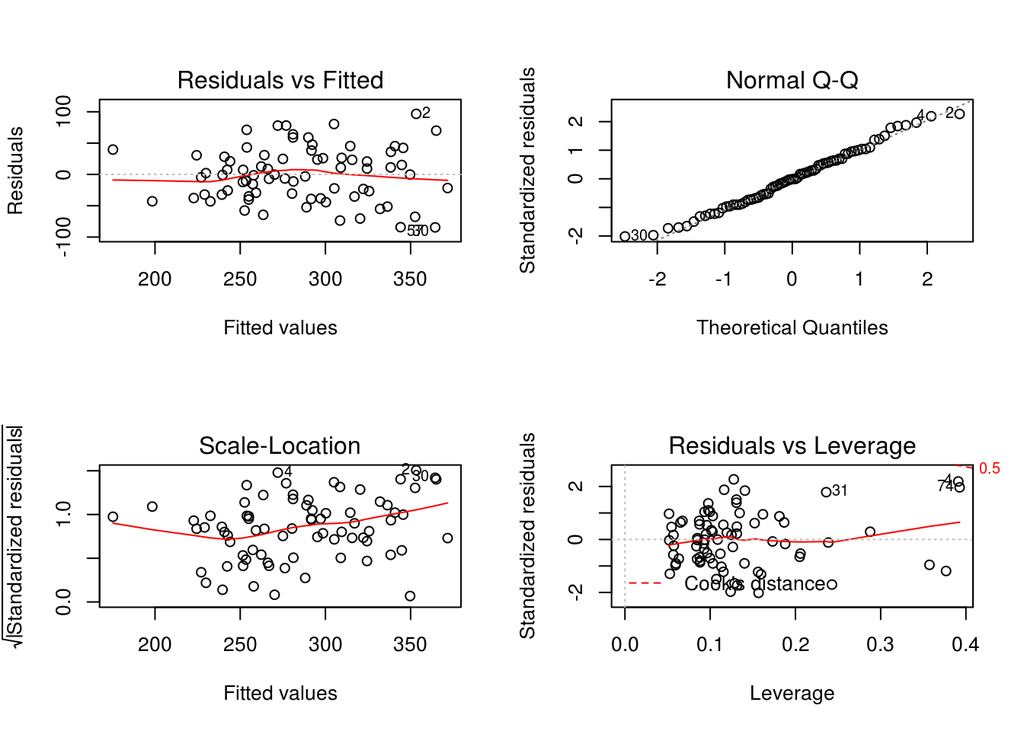

```r
par(mfrow = c(2, 2))
plot(model1)
```

The model we chose in the end of prject 1: multiple r squared of .4959 which is decent but not good not a great f-statistic great p-value

#### b. Create a second candidate model by using regsubsets over the entire data set. You can decide whether you prefer overall selection, forward selection, or backward selection, and you can decide which statistic you will use to determine the best model from the regsubsets process. Just conduct a justifiable model selection process and report the predictors in your final model.

```r
library(leaps)
regfit.full= regsubsets(price~.,Housing)
summary(regfit.full)
```

```
Subset selection object
Call: regsubsets.formula(price ~ ., Housing)
13 Variables  (and intercept)
                Forced in Forced out
size                FALSE      FALSE
lot                 FALSE      FALSE
bath                FALSE      FALSE
bedrooms            FALSE      FALSE
agestandardized     FALSE      FALSE
garagesize          FALSE      FALSE
statuspen           FALSE      FALSE
statussld           FALSE      FALSE
elemcrest           FALSE      FALSE
elemedge            FALSE      FALSE
elemedison          FALSE      FALSE
elemharris          FALSE      FALSE
elemparker          FALSE      FALSE
1 subsets of each size up to 8
Selection Algorithm: exhaustive
         size lot bath bedrooms agestandardized garagesize statuspen statussld
1  ( 1 ) " "  " " " "  " "      " "             "*"        " "       " "
2  ( 1 ) " "  " " " "  " "      " "             "*"        " "       " "
3  ( 1 ) " "  " " " "  " "      " "             "*"        " "       " "
4  ( 1 ) " "  "*" " "  " "      " "             "*"        " "       " "
5  ( 1 ) "*"  "*" " "  " "      " "             " "        " "       "*"
6  ( 1 ) "*"  "*" " "  "*"      " "             " "        " "       "*"
7  ( 1 ) "*"  "*" " "  "*"      " "             " "        " "       "*"
8  ( 1 ) "*"  "*" " "  "*"      " "             "*"        " "       "*"
         elemcrest elemedge elemedison elemharris elemparker
1  ( 1 ) " "       " "      " "        " "        " "
2  ( 1 ) " "       " "      "*"        " "        " "
3  ( 1 ) " "       " "      "*"        "*"        " "
4  ( 1 ) " "       " "      "*"        "*"        " "
5  ( 1 ) " "       " "      "*"        "*"        " "
6  ( 1 ) " "       " "      "*"        "*"        " "
7  ( 1 ) " "       " "      "*"        "*"        "*"
8  ( 1 ) " "       " "      "*"        "*"        "*"
```

```r
library(leaps)
regfit.full <- regsubsets(price ~.,data = Housing, nvmax=13, really.big = TRUE)

reg.summary <- summary(regfit.full)

names(reg.summary)
```

```
[1] "which"  "rsq"    "rss"    "adjr2"  "cp"     "bic"    "outmat" "obj"
```

```r
reg.summary$rsq
```

```
 [1] 0.1284406 0.2640426 0.3486598 0.4198205 0.4715142 0.5016191 0.5152707
 [8] 0.5254678 0.5360825 0.5387511 0.5398030 0.5401021 0.5401115
```

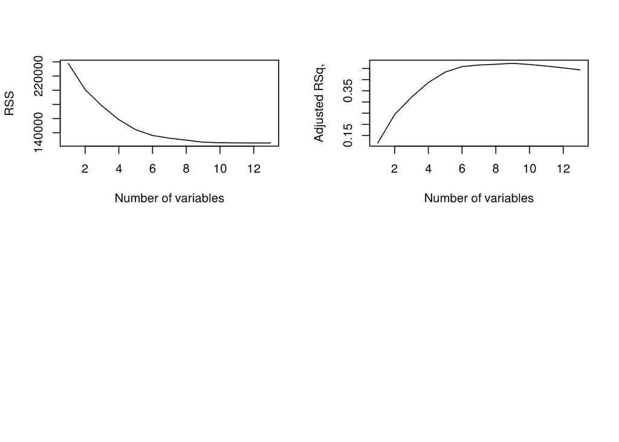

```r
par(mfrow = c(2,2))
plot(reg.summary$rss, xlab="Number of variables", ylab = "RSS", type = "l")
plot(reg.summary$adjr2, xlab="Number of variables", ylab = "Adjusted RSq,", type = "l")
```

```r
which.max(reg.summary$adjr2)
```

```
[1] 9
```

```r
plot(reg.summary$cp,xlab="Number of Variables",ylab="Cp",type='l')
which.min(reg.summary$cp)
```

```
[1] 6
```

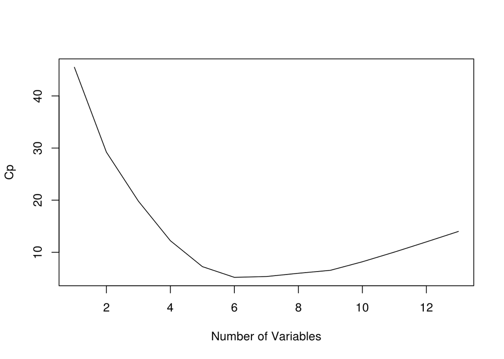

```r
points(6,reg.summary$adjr2[6], col="red",cex=2,pch=20)
```

```r
which.min(reg.summary$bic)
```

```
[1] 6
```

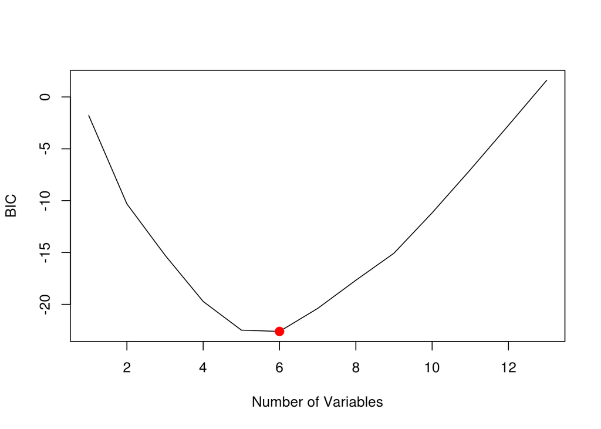

```r
plot(reg.summary$bic,xlab="Number of Variables",ylab="BIC",type='l')
points(6,reg.summary$bic[6],col="red",cex=2,pch=20)
```

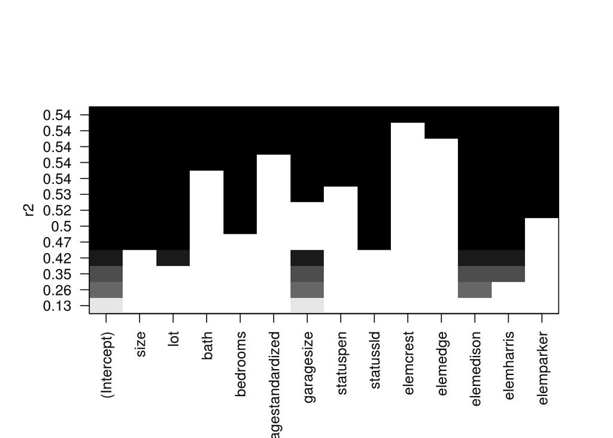

```r
plot(regfit.full,scale ="r2")
```

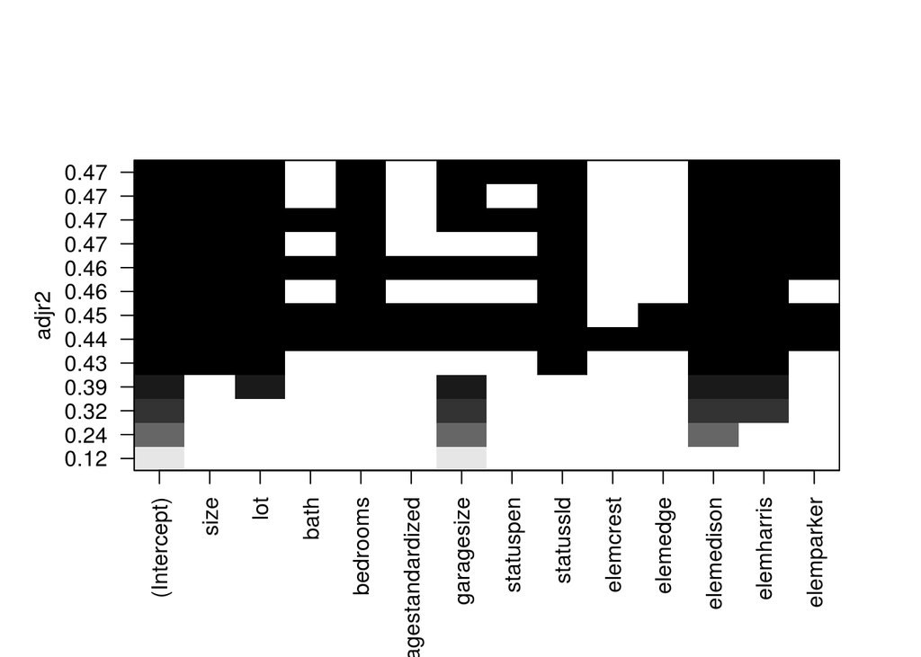

```r
plot(regfit.full,scale ="adjr2")
```

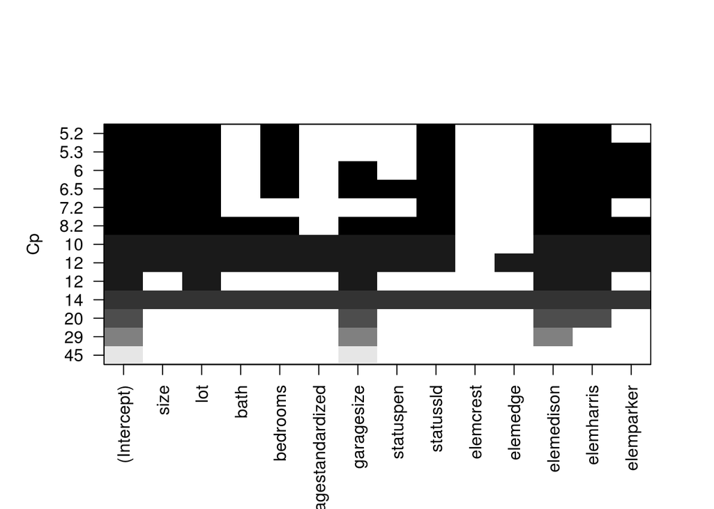

```r
plot(regfit.full,scale ="Cp")
```

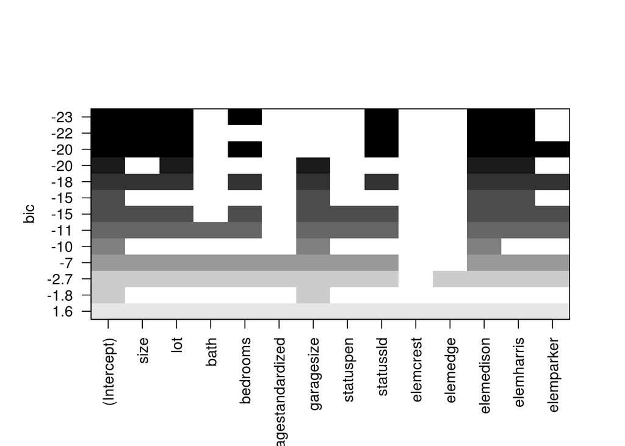

```r
plot(regfit.full,scale ="bic")
```

```r
coef(regfit.full,9)
```

```
(Intercept)        size         lot    bedrooms  garagesize   statuspen
 117.561602   80.541741    9.941952  -12.165964   10.299131  -18.752315
  statussld  elemedison  elemharris  elemparker
 -37.058833   77.458296   48.685858  -18.997921
```

```r
regfit.fwd <- regsubsets(price ~.,data = Housing, nvmax=13,method="forward")

summary(regfit.fwd)
```

```
Subset selection object
Call: regsubsets.formula(price ~ ., data = Housing, nvmax = 13, method = "forward")
13 Variables  (and intercept)
                Forced in Forced out
size                FALSE      FALSE
lot                 FALSE      FALSE
bath                FALSE      FALSE
bedrooms            FALSE      FALSE
agestandardized     FALSE      FALSE
garagesize          FALSE      FALSE
statuspen           FALSE      FALSE
statussld           FALSE      FALSE
elemcrest           FALSE      FALSE
elemedge            FALSE      FALSE
elemedison          FALSE      FALSE
elemharris          FALSE      FALSE
elemparker          FALSE      FALSE
1 subsets of each size up to 13
Selection Algorithm: forward
          size lot bath bedrooms agestandardized garagesize statuspen statussld
1  ( 1 )  " "  " " " "  " "      " "             "*"        " "       " "
2  ( 1 )  " "  " " " "  " "      " "             "*"        " "       " "
3  ( 1 )  " "  " " " "  " "      " "             "*"        " "       " "
4  ( 1 )  " "  "*" " "  " "      " "             "*"        " "       " "
5  ( 1 )  " "  "*" " "  " "      " "             "*"        " "       "*"
6  ( 1 )  "*"  "*" " "  " "      " "             "*"        " "       "*"
7  ( 1 )  "*"  "*" " "  "*"      " "             "*"        " "       "*"
8  ( 1 )  "*"  "*" " "  "*"      " "             "*"        " "       "*"
9  ( 1 )  "*"  "*" " "  "*"      " "             "*"        "*"       "*"
10  ( 1 ) "*"  "*" "*"  "*"      " "             "*"        "*"       "*"
11  ( 1 ) "*"  "*" "*"  "*"      "*"             "*"        "*"       "*"
12  ( 1 ) "*"  "*" "*"  "*"      "*"             "*"        "*"       "*"
13  ( 1 ) "*"  "*" "*"  "*"      "*"             "*"        "*"       "*"
          elemcrest elemedge elemedison elemharris elemparker
1  ( 1 )  " "       " "      " "        " "        " "
2  ( 1 )  " "       " "      "*"        " "        " "
3  ( 1 )  " "       " "      "*"        "*"        " "
4  ( 1 )  " "       " "      "*"        "*"        " "
5  ( 1 )  " "       " "      "*"        "*"        " "
6  ( 1 )  " "       " "      "*"        "*"        " "
7  ( 1 )  " "       " "      "*"        "*"        " "
8  ( 1 )  " "       " "      "*"        "*"        "*"
9  ( 1 )  " "       " "      "*"        "*"        "*"
10  ( 1 ) " "       " "      "*"        "*"        "*"
11  ( 1 ) " "       " "      "*"        "*"        "*"
12  ( 1 ) " "       "*"      "*"        "*"        "*"
13  ( 1 ) "*"       "*"      "*"        "*"        "*"
```

```r
regfit.bwd <- regsubsets(price ~.,data = Housing, nvmax=13,method="backward")

summary(regfit.bwd)
```

```
Subset selection object
Call: regsubsets.formula(price ~ ., data = Housing, nvmax = 13, method = "backward")
13 Variables  (and intercept)
                Forced in Forced out
size                FALSE      FALSE
lot                 FALSE      FALSE
bath                FALSE      FALSE
bedrooms            FALSE      FALSE
agestandardized     FALSE      FALSE
garagesize          FALSE      FALSE
statuspen           FALSE      FALSE
statussld           FALSE      FALSE
elemcrest           FALSE      FALSE
elemedge            FALSE      FALSE
elemedison          FALSE      FALSE
elemharris          FALSE      FALSE
elemparker          FALSE      FALSE
1 subsets of each size up to 13
Selection Algorithm: backward
          size lot bath bedrooms agestandardized garagesize statuspen statussld
1  ( 1 )  " "  " " " "  " "      " "             " "        " "       " "
2  ( 1 )  " "  " " " "  " "      " "             " "        " "       " "
3  ( 1 )  " "  "*" " "  " "      " "             " "        " "       " "
4  ( 1 )  " "  "*" " "  " "      " "             " "        " "       "*"
5  ( 1 )  "*"  "*" " "  " "      " "             " "        " "       "*"
6  ( 1 )  "*"  "*" " "  "*"      " "             " "        " "       "*"
7  ( 1 )  "*"  "*" " "  "*"      " "             " "        " "       "*"
8  ( 1 )  "*"  "*" " "  "*"      " "             "*"        " "       "*"
9  ( 1 )  "*"  "*" " "  "*"      " "             "*"        "*"       "*"
10  ( 1 ) "*"  "*" "*"  "*"      " "             "*"        "*"       "*"
11  ( 1 ) "*"  "*" "*"  "*"      "*"             "*"        "*"       "*"
12  ( 1 ) "*"  "*" "*"  "*"      "*"             "*"        "*"       "*"
13  ( 1 ) "*"  "*" "*"  "*"      "*"             "*"        "*"       "*"
          elemcrest elemedge elemedison elemharris elemparker
1  ( 1 )  " "       " "      "*"        " "        " "
2  ( 1 )  " "       " "      "*"        "*"        " "
3  ( 1 )  " "       " "      "*"        "*"        " "
4  ( 1 )  " "       " "      "*"        "*"        " "
5  ( 1 )  " "       " "      "*"        "*"        " "
6  ( 1 )  " "       " "      "*"        "*"        " "
7  ( 1 )  " "       " "      "*"        "*"        "*"
8  ( 1 )  " "       " "      "*"        "*"        "*"
9  ( 1 )  " "       " "      "*"        "*"        "*"
10  ( 1 ) " "       " "      "*"        "*"        "*"
11  ( 1 ) " "       " "      "*"        "*"        "*"
12  ( 1 ) " "       "*"      "*"        "*"        "*"
13  ( 1 ) "*"       "*"      "*"        "*"        "*"
```

```r
coef(regfit.fwd,9)
```

```
(Intercept)        size         lot    bedrooms  garagesize   statuspen
 117.561602   80.541741    9.941952  -12.165964   10.299131  -18.752315
  statussld  elemedison  elemharris  elemparker
 -37.058833   77.458296   48.685858  -18.997921
```

```r
coef(regfit.bwd,9)
```

```
(Intercept)        size         lot    bedrooms  garagesize   statuspen
 117.561602   80.541741    9.941952  -12.165964   10.299131  -18.752315
  statussld  elemedison  elemharris  elemparker
 -37.058833   77.458296   48.685858  -18.997921
```

```r
#used backward stepwise selection
model2 <- lm(price ~ size + lot + bedrooms + status + elem + garagesize,  data = Housing)
summary(model2)
```

```
Call:
lm(formula = price ~ size + lot + bedrooms + status + elem +
    garagesize, data = Housing)

Residuals:
    Min      1Q  Median      3Q     Max
-91.638 -29.448  -1.418  26.074 105.480

Coefficients:
            Estimate Std. Error t value Pr(>|t|)
(Intercept)  114.474     54.760   2.090  0.04055 *
size          80.711     27.633   2.921  0.00482 **
lot           10.047      3.532   2.845  0.00596 **
bedrooms     -12.405      8.564  -1.449  0.15235
statuspen    -19.833     16.211  -1.223  0.22566
statussld    -37.997     13.723  -2.769  0.00735 **
elemcrest      1.698     33.706   0.050  0.95998
elemedge       6.138     28.572   0.215  0.83059
elemedison    82.385     29.561   2.787  0.00700 **
elemharris    53.632     29.951   1.791  0.07808 .
elemparker   -14.254     29.637  -0.481  0.63220
garagesize     9.633      8.685   1.109  0.27149
---
Signif. codes:  0 '***' 0.001 '**' 0.01 '*' 0.05 '.' 0.1 ' ' 1

Residual standard error: 44.46 on 64 degrees of freedom
Multiple R-squared:  0.5366,    Adjusted R-squared:  0.457
F-statistic: 6.738 on 11 and 64 DF,  p-value: 0.0000002292
```

We decided to use backwards selection so that the worst predictords would be removed first.

#### c. Create a training/test split of the data by which roughly half of the 76 observations are training data and half are test data.

```r
set.seed(13)
trainset <- sample(nrow(Housing), nrow(Housing) * 0.5, replace = FALSE)
train <- Housing[trainset,]
test <- Housing[-trainset,]
```

#### d. Now use regsubsets over only the training data to determine the number of predictors that should be in your final model. Then use regsubsets over the entire data set with the determined number of variables to determine your third candidate model.

```r
regfit.best <- regsubsets(price ~ size + lot + bath + bedrooms + agestandardized + garagesize + status + elem, data = train, nvmax = 13)
```

```r
test.mat=model.matrix(price ~ size + lot + bath + bedrooms + agestandardized + garagesize + status + elem, data = test, nvmax = 13)
```

```r
val.errors = rep(NA, 13)
for(i in 1:13) {
coefi=coef(regfit.best,id=i)
pred=test.mat[,names(coefi)]%*%coefi
val.errors[i] = mean((test$price-pred)^2)
}
```

```r
val.errors
```

```
 [1] 3443.029 3794.346 3344.693 3056.766 2947.021 3274.618 3756.869 4251.184
 [9] 3936.372 3813.730 3611.195 3413.396 3412.908
```

```r
which.min(val.errors)
```

```
[1] 5
```

```r
coef(regfit.best,5 )
```

```
(Intercept)        bath  garagesize   elemcrest  elemedison  elemharris
  150.31667    28.84133    25.82204    45.61520    81.12830    44.66229
```

Our best model appears to be the fifth model as it has the smallest valiedation error.

```r
model3 <- lm(price ~ size + lot + status + elem, data = Housing)
summary(model3)
```

```
Call:
lm(formula = price ~ size + lot + status + elem, data = Housing)

Residuals:
    Min      1Q  Median      3Q     Max
-87.704 -31.737  -0.412  30.927 107.246

Coefficients:
            Estimate Std. Error t value Pr(>|t|)
(Intercept)   85.125     53.177   1.601 0.114202
size          78.947     26.243   3.008 0.003717 **
lot           12.812      3.391   3.779 0.000341 ***
statuspen    -19.024     16.558  -1.149 0.254747
statussld    -47.346     12.998  -3.643 0.000532 ***
elemcrest     -9.363     34.047  -0.275 0.784186
elemedge       6.163     28.597   0.216 0.830031
elemedison    78.760     29.894   2.635 0.010484 *
elemharris    59.572     30.315   1.965 0.053611 .
elemparker   -19.335     29.874  -0.647 0.519739
---
Signif. codes:  0 '***' 0.001 '**' 0.01 '*' 0.05 '.' 0.1 ' ' 1

Residual standard error: 45.5 on 66 degrees of freedom
Multiple R-squared:  0.4995,    Adjusted R-squared:  0.4313
F-statistic:  7.32 on 9 and 66 DF,  p-value: 0.0000002621
```

We have an ok but not great r squared, a bad f-statistic, and a good p-value

#### e. Next, use either Ridge Regression or Lasso Regression with the training data, and use cross validation via the cv.glmnet function to determine the best λ value. The model from this step with the best λ value will be your fourth candidate model.

```r
library(Matrix)
set.seed(13)

train.m<-model.matrix(price~.,data=train)
test.m<-model.matrix(price~.,data=test)



grid<-10^seq(4,-2,length=100)

library(glmnet)
ridge<-glmnet(train.m,train$price,alpha=0,lambda=grid,thresh = 1e-12)


cv.ridge<-cv.glmnet(train.m,train$price,alpha=0,lambda=grid,thresh=1e-12)


ridgebestlam<-cv.ridge$lambda.min
ridgebestlam
```

```
[1] 57.22368
```

The best $\lamba$ for the ridge approach is 57.22368.

```r
set.seed(13)
pred.ridge<-predict(ridge,s=ridgebestlam,newx =test.m)

mean((test$price-pred.ridge)^2)
```

```
[1] 2615.983
```

The mean squared error of the ridge regression model is 2615.983

#### f. Finally, use either principal components regression or partial least squares regression for the training data. Use cross validation (see the class notes or the Chapter 6 Lab from the text) to help you determine the number of components in the model and briefly explain your choice. This model will be your 5th candidate model.

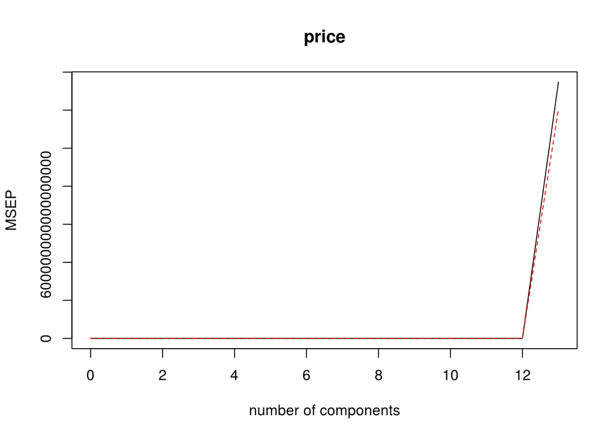

```r
library(pls)
plsrmodel<-plsr(price~.,data=train,scale=TRUE,validation="CV")

validationplot(plsrmodel,val.type="MSEP")
```

M=12 in this case.

```r
predict.plsr<-predict(plsrmodel,test,ncomp=12)
mean((test$price-predict.plsr)^2)
```

```
[1] 3411.355
```

In this model, the MSE is 3411.355

#### g. For each of the five candidate models, calculate the mean square error for predicting the outcomes in the test data set that you created in part c. Based on this comparison, which model do you prefer for this situation?

```r
set.seed(13)
pred.m1<-predict(model1,test)
pred.m2<-predict(model2,test)
pred.m3<-predict(model3,test)
```

```r
test.avg <- mean(test$price)
#WE NEED TO PUT ALL THE MODELS HERE
model1.r2 <- 1 - mean((pred.m1 - test$price)^2) / mean((test.avg - test$price)^2)

model2.r2 <- 1 - mean((pred.m2 - test$price)^2) / mean((test.avg - test$price)^2)

model3.r2 <- 1 - mean((pred.m3 - test$price)^2) / mean((test.avg - test$price)^2)
#Ridge model
ridge.r2 <- 1 - mean((pred.ridge - test$price)^2) / mean((test.avg - test$price)^2)
#PLS model
pls.r2 <- 1 - mean((predict.plsr - test$price)^2) / mean((test.avg - test$price)^2)
```

```r
model1.r2
```

```
[1] 0.5918734
```

```r
model2.r2
```

```
[1] 0.6308174
```

```r
model3.r2
```

```
[1] 0.6184458
```

```r
ridge.r2
```

```
[1] 0.254608
```

```r
pls.r2
```

```
[1] 0.02797663
```

As shown here, the second model, using regsubsets over the entire dataset with backward selection, has the highest and most favorable r squared value, followed closely by the regsubsets on the training data.

```r
#MSE
#Model1
set.seed(13)
pred.m1<-predict(model1,test)
mean((test$price-pred.m1)^2)
```

```
[1] 1432.336
```

```r
#Model2
pred.m2<-predict(model2,test)
mean((test$price-pred.m2)^2)
```

```
[1] 1295.661
```

```r
#Model3
pred.m3<-predict(model3,test)
mean((test$price-pred.m3)^2)
```

```
[1] 1339.08
```

```r
#Ridge
pred.ridge<-predict(ridge,s=ridgebestlam,newx =test.m)
mean((test$price-pred.ridge)^2)
```

```
[1] 2615.983
```

```r
#PSLR
predict.plsr<-predict(plsrmodel,test,ncomp=12)
mean((test$price-predict.plsr)^2)
```

```
[1] 3411.355
```

The highest MSE is for the PSLR model, but it is still unlikely that it is a good model at all because the r-squared value was so bad.

```r
summary(model3)
```

```
Call:
lm(formula = price ~ size + lot + status + elem, data = Housing)

Residuals:
    Min      1Q  Median      3Q     Max
-87.704 -31.737  -0.412  30.927 107.246

Coefficients:
            Estimate Std. Error t value Pr(>|t|)
(Intercept)   85.125     53.177   1.601 0.114202
size          78.947     26.243   3.008 0.003717 **
lot           12.812      3.391   3.779 0.000341 ***
statuspen    -19.024     16.558  -1.149 0.254747
statussld    -47.346     12.998  -3.643 0.000532 ***
elemcrest     -9.363     34.047  -0.275 0.784186
elemedge       6.163     28.597   0.216 0.830031
elemedison    78.760     29.894   2.635 0.010484 *
elemharris    59.572     30.315   1.965 0.053611 .
elemparker   -19.335     29.874  -0.647 0.519739
---
Signif. codes:  0 '***' 0.001 '**' 0.01 '*' 0.05 '.' 0.1 ' ' 1

Residual standard error: 45.5 on 66 degrees of freedom
Multiple R-squared:  0.4995,    Adjusted R-squared:  0.4313
F-statistic:  7.32 on 9 and 66 DF,  p-value: 0.0000002621
```

The r-square of .4995 means that the model does a good job of explaining close to half of the data

Also, the p-value suggested high significance and that the model is a good fit for the data